# Introduction to single-cell RNA-seq analysis

# 11 Differential Abundance Analysis

In the previous section we discussed how we can perform differential expression analysis using pseudo-bulk samples, when multiple *biological replicates* are available in a multi-condition experiment. Differential expression analysis addresses the question of whether a gene has a different average expression between the two groups being compared. However, another useful question to address is whether the *cell composition* also differs between conditions. We could imagine that B-cell precursor populations expand in leukaemia samples, leading to reduced relative abundance of T and NK cells.

This type of analysis is referred to as **differential abundance analysis**.

We start our analysis, as always, by loading our packages:

```r
# load packages
library(BiocParallel)
library(scran)
library(scater)
library(miloR)
library(tidyverse)
library(patchwork)
```

We will continue working with our PBMMC and ETV6-RUNX1 samples, as we did in the differential expression section. Note that we’ve modified the data used in this section to make sure we have some significant DA results to show (in reality, the original data did not show any differences).

```r
# Load data
# Note: this data has been modified for the purpose of this demonstration
# To make sure we have some significant DA results to show.
sce <- readRDS("RObjects/MiloDemo.sce.rds")
```

One method to perform DA analysis is to simply count how many cells occur in each label + condition combination and then test for differences in the counts between the two conditions.

```r
table(sce$label, sce$SampleName)
```

```
##
##                      ETV6RUNX1-1 ETV6RUNX1-2 ETV6RUNX1-3 ETV6RUNX1-4 PBMMC-1
##   B (c3)                     548         544         563         550      66
##   B (c6)                     316         495          61         264     133
##   B (c5)                     115         327         124         910      86
##   Monocytes (c14)              5           6           3           9     244
##   T (c2)                       2          28         336          40    1180
##   Erythrocytes (c8)            4          17         259         898     404
##   CD20+ B (c10)                7         113         464         141     420
##   NK T (c11)                   3          13          51          27     390
##   T (c19)                     11          61          24          18      37
##   Unknown (c9)                16          99          58          16       3
##   B (c1)                       6        4380          70          16     356
##   T (c13)                      7          41          49          28       3
##   B (c4)                       7          43          81        1438      97
##   B (c7)                       3         464          75          12       1
##   B (c12)                      6          76        1580          84      27
##   B (c16)                      3         105           7         850       7
##   Monocytes (c21)              1           3          15          36      70
##   T (c18)                      0           9          10           2       1
##   B (c23)                      0          23           8           5      30
##   Erythrocytes (c15)           0           5          80         909       8
##   B (c22)                      0           2           0           1      26
##   Erythrocytes (c17)           0           0           3           6     319
##   T (c20)                      0           0           0           0     132
##
##                      PBMMC-2 PBMMC-3
##   B (c3)                  61      48
##   B (c6)                 100     120
##   B (c5)                  76      85
##   Monocytes (c14)        286     258
##   T (c2)                1172    1201
##   Erythrocytes (c8)      426     378
##   CD20+ B (c10)          401     392
##   NK T (c11)             407     440
##   T (c19)                 29      37
##   Unknown (c9)             1       0
##   B (c1)                 324     331
##   T (c13)                  3       0
##   B (c4)                 100      93
##   B (c7)                   2       8
##   B (c12)                 27      29
##   B (c16)                 10       6
##   Monocytes (c21)         93      91
##   T (c18)                  1       0
##   B (c23)                 24      28
##   Erythrocytes (c15)       7      13
##   B (c22)                 30      21
##   Erythrocytes (c17)     338     319
##   T (c20)                107     109
```

As these are count data, statistical methods used in flow-cytometry have been adapted to test for differences in cell abundance from such a matrix of counts. This is the approach used in the [Differential Abundance Analysis](http://bioconductor.org/books/3.16/OSCA.multisample/differential-abundance.html) chapter in the OSCA book. However, this approach does not take into account the fact that cells are not independent observations, but rather are related to each other in a complex way.

This approach also relies on a fixed set of clusters determined by us beforehand, which can be limiting in cases where the changes in abundance are more continuous (e.g. along a developmental trajectory, or where cell states are not completely discrete). To address this limitation, [Dann et al. (2022)](https://doi.org/10.1038/s41587-021-01033-z) developed a method where cell abundance differences are tested along neighbourhoods of cells on a KNN graph. This means that the results aren’t dependent on our clustering results, and are instead treated in a more “continuous” way.

To address this issue, we can use a method called **Milo**.

- Building a k-nearest neighbours (KNN) graph
- Sampling representative neighbourhoods in the graph (for computational efficiency)
- Testing for differential abundance of conditions in all neighbourhoods
- Accounting for multiple hypothesis testing using a weighted FDR procedure that accounts for the overlap of neighbourhoods

As the package was written by the authors of the `scater`/`scran` suite of packages for Bioconductor the structures unpinning it are based on `SingleCellExperiment`. The previous add-on section demonstrated how we can easily convert our `Seurat` object to a `SingleCellExperiment` object. The next step in the analysis is to turn our single cell object into a `Milo` object. This is very similar to the `SingleCellExperiment` object, but also includes information about the neighbourhood graphs that are built during the analysis.

```r
# check the contents of the object
sce
```

```
## class: SingleCellExperiment
## dim: 28343 30167
## metadata(0):
## assays(2): counts logcounts
## rownames(28343): ENSG00000238009 ENSG00000241860 ... FAM41AY1 FAM224B
## rowData names(0):
## colnames(30167): ETV6RUNX1-1_AAACCTGAGACTTTCG-1
##   ETV6RUNX1-1_AAACCTGGTCTTCAAG-1 ... PBMMC-3_TTTGTCATCAGTTGAC-1
##   PBMMC-3_TTTGTCATCTCGTTTA-1
## colData names(12): orig.ident nCount_RNA ... ident label
## reducedDimNames(3): PCA HARMONY UMAP
## mainExpName: SCT
## altExpNames(1): RNA
```

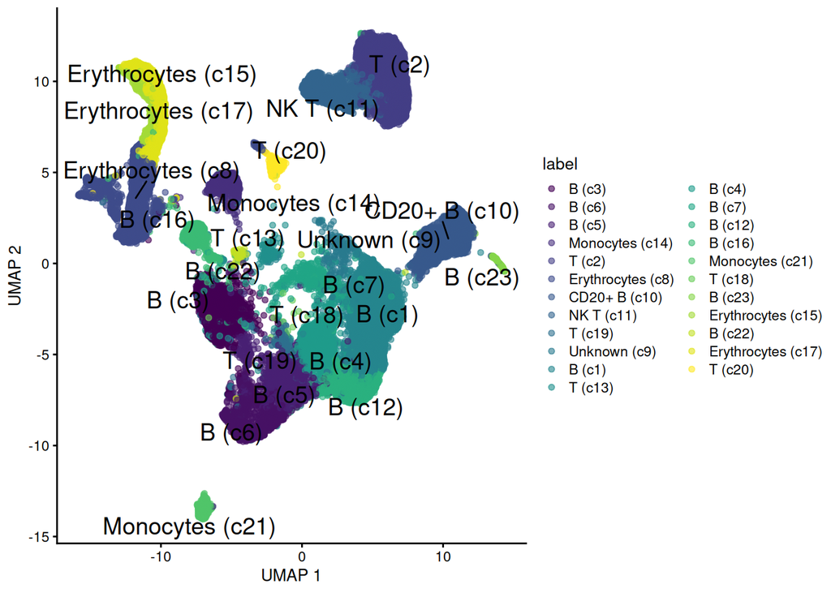

```r
# plot UMAP done on the batch-corrected data
plotReducedDim(sce, dimred = "UMAP",
               colour_by = "label",
               text_by = "label")
```

```r
# convert to a Milo object
milo <- Milo(sce)

milo
```

```
## class: Milo
## dim: 28343 30167
## metadata(0):
## assays(2): counts logcounts
## rownames(28343): ENSG00000238009 ENSG00000241860 ... FAM41AY1 FAM224B
## rowData names(0):
## colnames(30167): ETV6RUNX1-1_AAACCTGAGACTTTCG-1
##   ETV6RUNX1-1_AAACCTGGTCTTCAAG-1 ... PBMMC-3_TTTGTCATCAGTTGAC-1
##   PBMMC-3_TTTGTCATCTCGTTTA-1
## colData names(12): orig.ident nCount_RNA ... ident label
## reducedDimNames(3): PCA HARMONY UMAP
## mainExpName: SCT
## altExpNames(0):
## nhoods dimensions(2): 1 1
## nhoodCounts dimensions(2): 1 1
## nhoodDistances dimension(1): 0
## graph names(0):
## nhoodIndex names(1): 0
## nhoodExpression dimension(2): 1 1
## nhoodReducedDim names(0):
## nhoodGraph names(0):
## nhoodAdjacency dimension(2): 1 1
```

Notice how there are now several slots with prefix `nhoods`, which we will explore as we go through the analysis.

## 11.1 Construct KNN graph

```r
# Build KNN graph ----
```

The first step in our analysis is to build a KNN graph from our cells. This is very similar to what we did earlier in the clustering session, except now the graph will be stored *inside* the object:

```r
# add KNN graph to Milo object
milo <- buildGraph(milo,
                   k = 48,
                   d = 20,
                   reduced.dim = "HARMONY",
                   BPPARAM = MulticoreParam(7))
```

```
## Constructing kNN graph with k:48
```

A couple of things to note about this:

The object now has a new object inside the `graph` slot, which a standard object type from the [igraph package](https://igraph.org/r/):

```r
# the graph is stored as a standard igraph object
graph(milo)
```

```
## IGRAPH 0945317 U--- 30167 1035669 --
## + edges from 0945317:
##  [1] 1--   12 1--   53 1--   93 1--   95 1--  111 1--  116 1--  135 1--  169
##  [9] 1--  192 1--  194 1--  217 1--  247 1--  287 1--  343 1--  402 1--  430
## [17] 1--  487 1--  500 1--  590 1--  620 1--  686 1--  710 1--  740 1--  786
## [25] 1--  912 1--  962 1-- 1061 1-- 1066 1-- 1145 1-- 1151 1-- 1196 1-- 1213
## [33] 1-- 1242 1-- 1368 1-- 1377 1-- 1402 1-- 1457 1-- 1487 1-- 1544 1-- 1553
## [41] 1-- 1557 1-- 1574 1-- 1602 1-- 1641 1-- 1741 1-- 1760 1-- 1818 1-- 1893
## [49] 1-- 1930 1-- 1978 1-- 2002 1-- 2022 1-- 2063 1-- 2080 1-- 2241 1-- 2265
## [57] 1-- 2347 1-- 2483 1-- 2507 1-- 2578 1-- 2654 1--20571 1--20652 1--25307
## [65] 1--25366 1--26113 1--26814 1--27026 1--27331 1--27795 1--27928 1--28640
## + ... omitted several edges
```

## 11.2 Define neighbourhoods

The next step in the analysis is to define cell neighbourhoods. This essentially consists of picking a focal cell and counting how many other cells it is connected to in the graph (and how many come from each group under comparison). However, if we did this for every single cell in the data, it could get computationally quite intractable. Instead, *Milo* implements a sampling step, where so-called “index cells” are sampled from the larger graph, and those will be the neighbourhoods used in the DA analysis.

This is done with the `makeNhodds()` function:

```r
# sample index cells to define neighbourhoods
milo <- makeNhoods(milo,
                   prop = 0.1,
                   k = 48,
                   d = 20,
                   reduced_dims = "HARMONY")

# check our object again
milo
```

```
## class: Milo
## dim: 28343 30167
## metadata(0):
## assays(2): counts logcounts
## rownames(28343): ENSG00000238009 ENSG00000241860 ... FAM41AY1 FAM224B
## rowData names(0):
## colnames(30167): ETV6RUNX1-1_AAACCTGAGACTTTCG-1
##   ETV6RUNX1-1_AAACCTGGTCTTCAAG-1 ... PBMMC-3_TTTGTCATCAGTTGAC-1
##   PBMMC-3_TTTGTCATCTCGTTTA-1
## colData names(12): orig.ident nCount_RNA ... ident label
## reducedDimNames(3): PCA HARMONY UMAP
## mainExpName: SCT
## altExpNames(0):
## nhoods dimensions(2): 30167 2324
## nhoodCounts dimensions(2): 1 1
## nhoodDistances dimension(1): 0
## graph names(1): graph
## nhoodIndex names(1): 2324
## nhoodExpression dimension(2): 1 1
## nhoodReducedDim names(0):
## nhoodGraph names(0):
## nhoodAdjacency dimension(2): 1 1
```

Some things to note:

- `prop` is the proportion of cells to sample (the authors advise 0.1 - 0.2).
- `k` and `d` should be set the same as the *k* value used to build the original KNN graph. These values will be used for the graph-sampling algorithm used behind the scenes.

We can also see that our Milo object now has the `nhoods` slots populated. In this case, it indicates that the sampling algorithm picked 2324 index cells to form neighbourhoods for DA analysis.

One good QC metric to check at this stage is to create a histogram of cell counts per neighbourhood. Like we said earlier, when we set the value of *k* to define our KNN graph, we want to make sure the value is not too low, such that most neighbourhoods have very few cells, nor for it to be so high that we have very large (and presumably heterogenous) neighbourhoods.

Conveniently, `MiloR` has a plotting function just for this purpose:

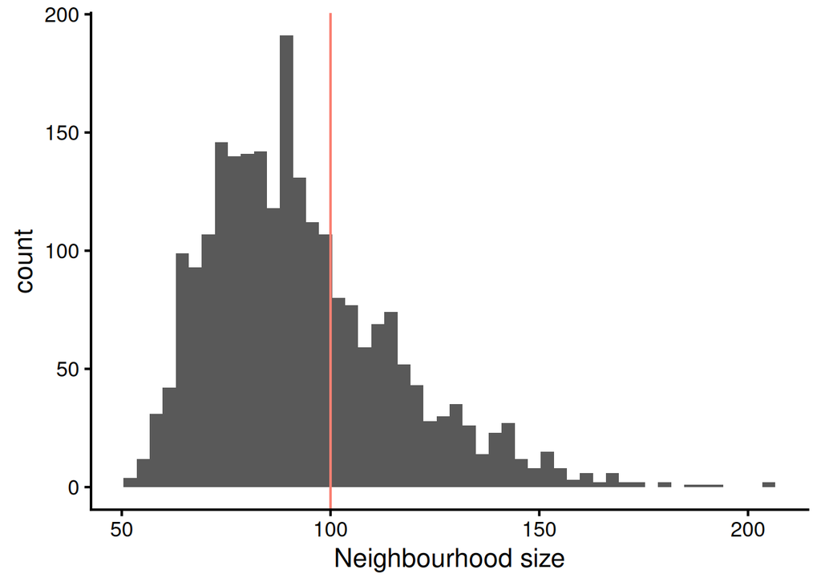

```r
# distribution of neighbourhood sizes
plotNhoodSizeHist(milo) +
  geom_vline(xintercept = 100, col = "salmon")
```

## 11.3 Counting cells

After defining our sample of neighbourhoods, the next step consists of counting how many cells there are in each neighbourhood for each sample replicate. In this step we need to define which column of our metadata we want to use to do the counting. We should count cells at the biological replicate leve, which in our case is stored in the `SampleName` column.

```r
# count cells in each neighbourhood
milo <- countCells(milo,
                   meta.data = colData(milo),
                   samples = "SampleName")

# Milo now has a counts matrix
head(nhoodCounts(milo))
```

```
## 6 x 7 sparse Matrix of class "dgCMatrix"
##   ETV6RUNX1-1 ETV6RUNX1-2 ETV6RUNX1-3 ETV6RUNX1-4 PBMMC-1 PBMMC-2 PBMMC-3
## 1           .           1           1           1      27      22      29
## 2           .         111          15           .       .       .       .
## 3          23          19          27          21       .       .       .
## 4           .           .           .           .      18      28      28
## 5           .          87           .           .       .       .       2
## 6           .           5           .          11      38      21      21
```

The dimensions of the counts matrix corresponds to the number of neighbourhoods (rows) and samples (columns), in our case a 2324 by 7 matrix.

## 11.4 Neighbourhood connectivity

There is one more step that we need to do before we are ready to run our DA analysis. It consists of calculating the distances between each neighbourhood. As we said, the neighbourhoods on our graph may partially overlap, so when Milo corrects our p-values for multiple testing, it takes into account the spatial dependence of our tests. For example, neighbourhoods that are closer to each other may have similar p-values, and so we should avoid penalising them too much, otherwise we will sacrifice statistical power.

```r
# calculate distances between neighbourhoods - for p-value correction
# This step takes a few minutes
milo <- calcNhoodDistance(milo, d = 20, reduced.dim = "HARMONY")
```

## 11.5 Running DA tests

Finally, we are ready to run the actual differential abundance step. Similarly to the pseudo-bulk appproach for differential expression, `MiloR` takes advantage of the `edgeR` package and its negative binomial linear model implementation. This provides a suitable statistical model to account for over-dispersed count data, as is common with these kind of datasets.

First, we need to define a simple table with information about our samples - we will use this table to define our model formula (similarly to what we did in the differential expression step). In this case, we want to detect DA between our PBMMC and ETV6-RUNX1 sample groups, so we define a table based on those two groups. We could also include a batch column in this table, but to keep the demonstration simple we will skip this. We would normally do this if we know there is a batch effect that we want to account for it in DA testing.

```r
# define a table for our model design
sample_info <- unique(colData(milo)[, c("SampleName", "SampleGroup")])
rownames(sample_info) <- sample_info$SampleName
# order the table to match the order of samples in our counts matrix
sample_info <- sample_info[colnames(nhoodCounts(milo)), ]

sample_info
```

```
## DataFrame with 7 rows and 2 columns
##              SampleName SampleGroup
##                <factor>    <factor>
## ETV6RUNX1-1 ETV6RUNX1-1   ETV6RUNX1
## ETV6RUNX1-2 ETV6RUNX1-2   ETV6RUNX1
## ETV6RUNX1-3 ETV6RUNX1-3   ETV6RUNX1
## ETV6RUNX1-4 ETV6RUNX1-4   ETV6RUNX1
## PBMMC-1     PBMMC-1       PBMMC
## PBMMC-2     PBMMC-2       PBMMC
## PBMMC-3     PBMMC-3       PBMMC
```

Now we can do the DA test, explicitly defining our experimental design. In this case as discussed we will test the difference between sample groups. The `testNhoods` function calculates a Fold-change and corrected P-value for each neighbourhood, which indicates whether there is significant differential abundance between sample groups.

```r
# run DA test
da_results <- testNhoods(milo,
                         design = ~ SampleGroup,
                         design.df = sample_info,
                         reduced.dim = "HARMONY")

# results are returned as a data.frame
da_results %>%
  arrange(SpatialFDR) %>%
  head()
```

```
##       logFC    logCPM         F       PValue         FDR Nhood  SpatialFDR
## 1  6.353066  9.682331  61.68553 7.590678e-05 0.004369078     1 0.003461454
## 15 8.784424  9.715095 103.00022 2.965902e-04 0.004369078    15 0.003461454
## 17 7.710021  9.878173  60.70449 9.336862e-05 0.004369078    17 0.003461454
## 25 6.160069  9.837182  53.69824 1.388821e-04 0.004369078    25 0.003461454
## 35 8.822261  9.750387 103.99192 2.905231e-04 0.004369078    35 0.003461454
## 37 7.841412 10.004035  64.41996 7.690225e-05 0.004369078    37 0.003461454
```

## 11.6 Inspecting DA results

A good diagnostic plot to make after running our analysis is a histogram of p-values. We should expect a distribution with a peak close to 0 (corresponding to differentially abundant neighbourhoods) and tailing off towards 1. This [blog article](http://varianceexplained.org/statistics/interpreting-pvalue-histogram/) explains the different p-value histogram profiles you may see and what they can mean.

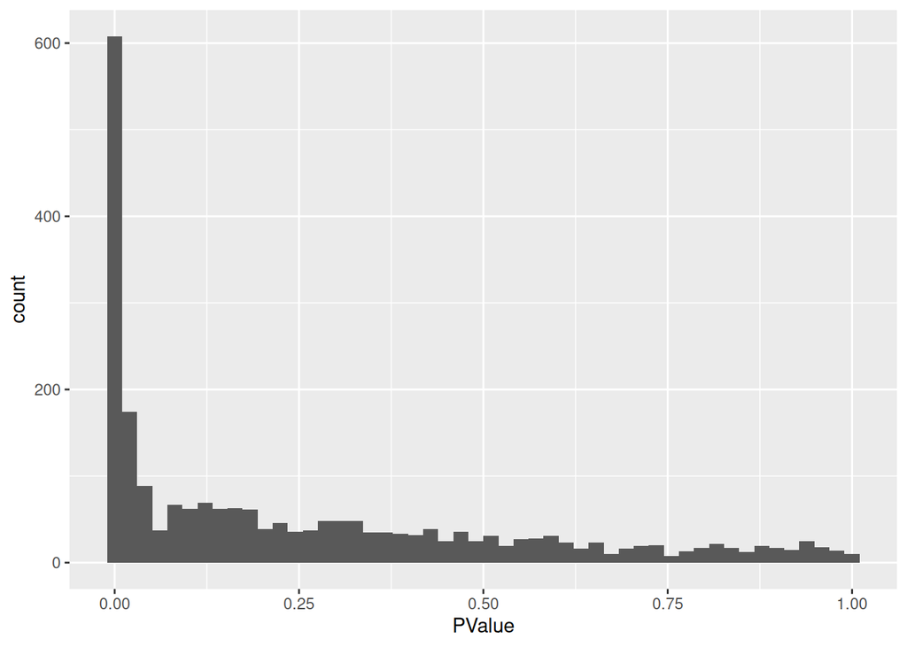

```r
# p-value histogram
ggplot(da_results, aes(PValue)) +
  geom_histogram(bins = 50)
```

Next, we can get an overview of our results as a volcano plot, marking a significance threshold of 10% FDR:

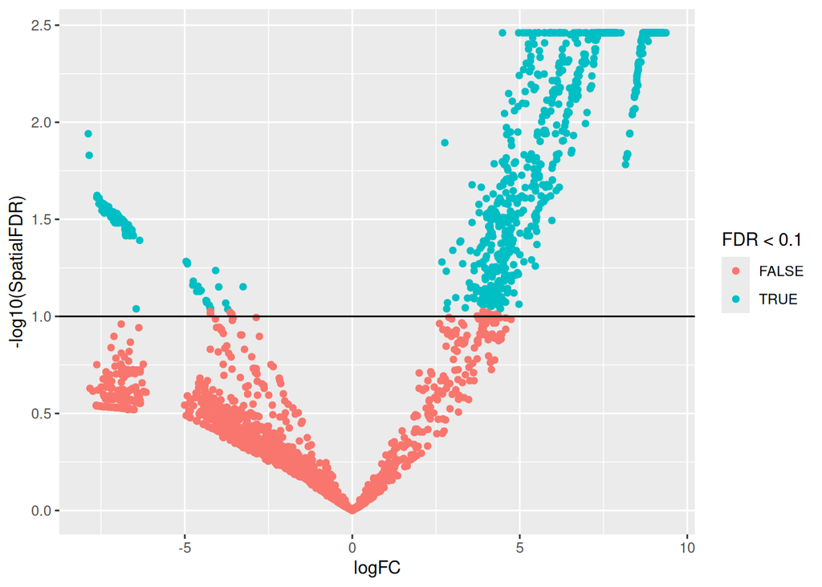

```r
# volcano plot
# each point in this plot corresponds to a neighbourhood (not a cell)
ggplot(da_results, aes(logFC, -log10(SpatialFDR))) +
  geom_point(aes(colour = FDR < 0.1)) +
  geom_hline(yintercept = 1)
```

As we can see, several neighbourhoods fall below our FDR threshold, indicating significant differential abundance of cells between PBMMC and ETV6-RUNX1 samples.

There is an unsual discontinuity in our logFC axis, suggesting a sudden change in abundance in some of our neighbourhoods. We can get a better idea of the fold changes by visualising them as a graph for our neighbourhoods (rather than the original single-cell graph, which would be too big to display). We can then super-impose this graph on our original UMAP (or t-SNE), to compare with our original analysis.

```r
# build neighbourhood graph embedding
milo <- buildNhoodGraph(milo)
```

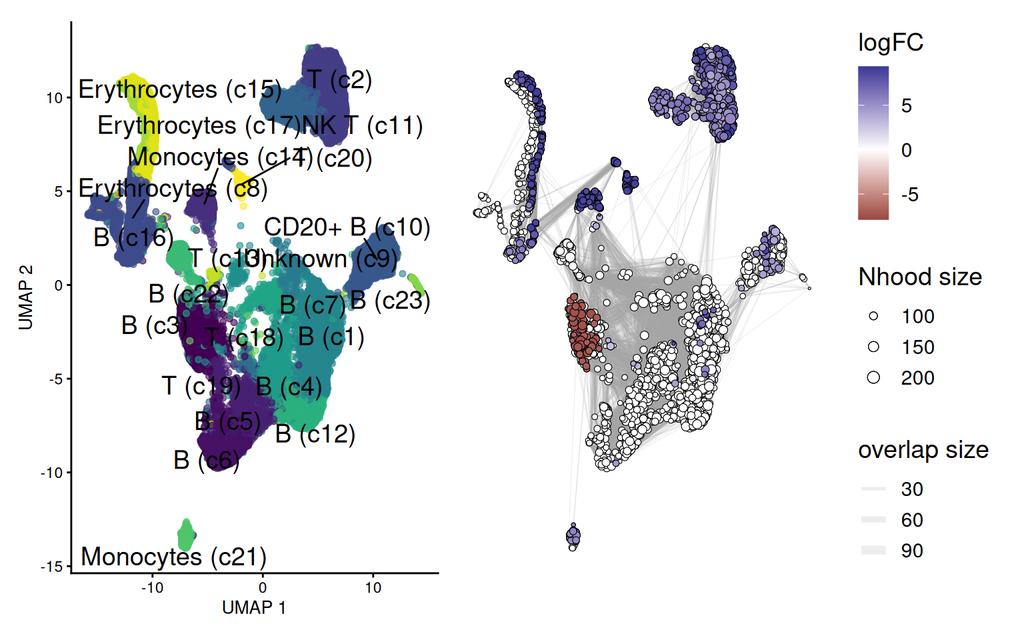

```r
# our original UMAP with our previously annotated cell labels
umap_plot <- plotReducedDim(milo,
                            dimred = "UMAP",
                            colour_by = "label",
                            text_by = "label") +
  theme(legend.position = "none")

# the neighbourhood map adjusted to match UMAP embedding
nh_graph_plot <- plotNhoodGraphDA(milo,
                                  da_results,
                                  res_column = "logFC",
                                  layout = "UMAP",
                                  alpha = 0.05)

# the two plots together side-by-side
umap_plot + nh_graph_plot +
  plot_layout(guides="collect")
```

Although we have annotations for our cells, these annotations at the moment are not present in the differential abundance table:

```r
head(da_results)
```

```
##       logFC   logCPM         F       PValue         FDR Nhood  SpatialFDR
## 1  6.353066 9.682331 61.685530 7.590678e-05 0.004369078     1 0.003461454
## 2 -7.494346 8.957664  3.951141 1.014005e-01 0.235307859     2 0.231165778
## 3 -7.063460 8.593517 17.084573 7.471359e-03 0.032334150     3 0.029750833
## 4  8.660067 9.599543 84.810279 4.502935e-04 0.004685037     4 0.003746897
## 5 -3.444498 8.604922  1.233463 3.024654e-01 0.464593214     5 0.449783234
## 6  4.200126 9.791865  8.975795 1.941770e-02 0.064191656     6 0.060118360
```

We can transfer our cell labels to the neighbourhood DA results, by simply counting how many cells within that neighbourhood share the same label, and assign the label with the highest counts.

```r
# annotate our neighbourhood DA results with our cell labels
da_results <- annotateNhoods(milo, da_results, coldata_col = "label")
head(da_results)
```

```
##       logFC   logCPM         F       PValue         FDR Nhood  SpatialFDR
## 1  6.353066 9.682331 61.685530 7.590678e-05 0.004369078     1 0.003461454
## 2 -7.494346 8.957664  3.951141 1.014005e-01 0.235307859     2 0.231165778
## 3 -7.063460 8.593517 17.084573 7.471359e-03 0.032334150     3 0.029750833
## 4  8.660067 9.599543 84.810279 4.502935e-04 0.004685037     4 0.003746897
## 5 -3.444498 8.604922  1.233463 3.024654e-01 0.464593214     5 0.449783234
## 6  4.200126 9.791865  8.975795 1.941770e-02 0.064191656     6 0.060118360
##                label label_fraction
## 1         NK T (c11)      1.0000000
## 2             B (c7)      0.9523810
## 3             B (c3)      1.0000000
## 4 Erythrocytes (c17)      1.0000000
## 5             B (c1)      0.9325843
## 6      CD20+ B (c10)      1.0000000
```

The result includes the fraction of cells in the neighbourhood that shared that label. We can look at the distribution of this fraction as a quality check:

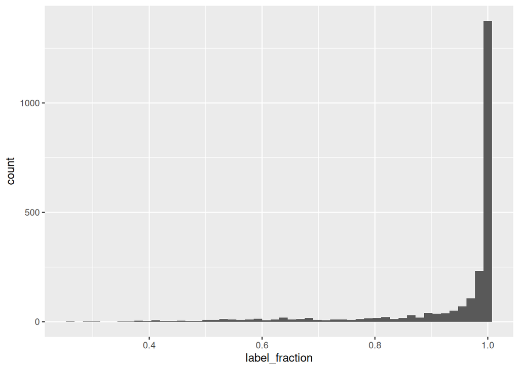

```r
# histogram of fraction of cells in the neighbourhood with the same label
ggplot(da_results, aes(label_fraction)) +
  geom_histogram(bins = 50)
```

We should expect the plot to be very biased towards 1, as is seen. This makes sense, since Milo’s neighbourhoods should be very similar to our previously-defined clusters. After all, both our clustering and *Milo* used KNN graphs as the starting point, and we’ve used the same settings for the *k* and *d* parameters in both steps of our analysis.

Despite most neighbourhoods being homogenous, some seem to have mixed labels. We can highlight these in our results table:

```r
# add "mixed" label to neighbourhoods with less 70% consistency
da_results$label <- ifelse(da_results$label_fraction < 0.7,
                           "Mixed",
                           da_results$label)

head(da_results)
```

```
##       logFC   logCPM         F       PValue         FDR Nhood  SpatialFDR
## 1  6.353066 9.682331 61.685530 7.590678e-05 0.004369078     1 0.003461454
## 2 -7.494346 8.957664  3.951141 1.014005e-01 0.235307859     2 0.231165778
## 3 -7.063460 8.593517 17.084573 7.471359e-03 0.032334150     3 0.029750833
## 4  8.660067 9.599543 84.810279 4.502935e-04 0.004685037     4 0.003746897
## 5 -3.444498 8.604922  1.233463 3.024654e-01 0.464593214     5 0.449783234
## 6  4.200126 9.791865  8.975795 1.941770e-02 0.064191656     6 0.060118360
##                label label_fraction
## 1         NK T (c11)      1.0000000
## 2             B (c7)      0.9523810
## 3             B (c3)      1.0000000
## 4 Erythrocytes (c17)      1.0000000
## 5             B (c1)      0.9325843
## 6      CD20+ B (c10)      1.0000000
```

Finally, we can visualise the distribution of DA fold changes in different labels.

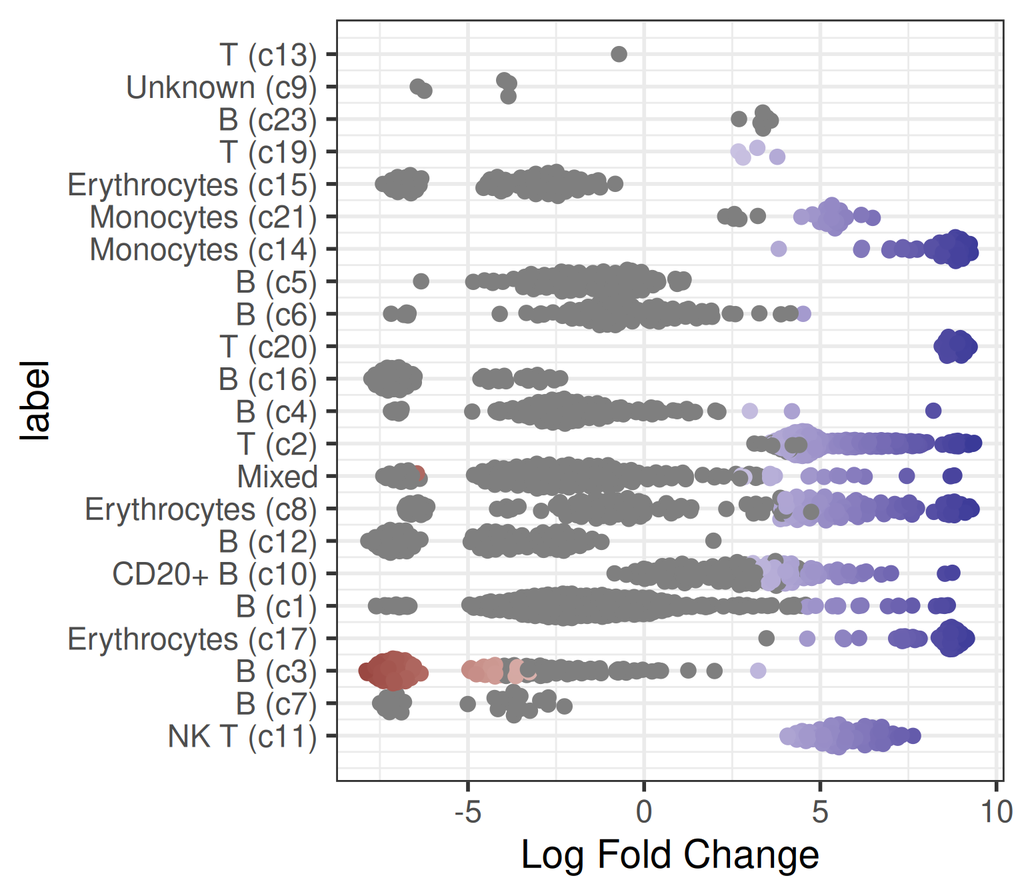

```r
# distribution of logFC across neighbourhood labels
plotDAbeeswarm(da_results, group.by = "label")
```

It is also worth noting that this analysis may also reveal uncorrected batch effects, which would lead to an artificial separation of our samples according to their group. As always, we should always proceed in our analysis with care and back our conclusions with further confirmatory experiments.

There are further downstream analysis possible to identify genes that differentiate between our different neighbourhoods. This is similar in spirit to the marker gene analysis we did earlier, but based on the neighbourhood graph constructed by Milo. You can consult the [package’s main vignette](https://bioconductor.org/packages/release/bioc/vignettes/miloR/inst/doc/milo_gastrulation.html#5_Finding_markers_of_DA_populations) to see examples of these downstream analysis.